# Financial_Analytics - CAPM

Guilherme, Helena, Sérgio e Vinícius

11/27/2020

# Objetivo

O objetivo dessa apresentação é analisar o valor obtido de $\beta$, do modelo CAPM para 4 diferentes ativos usando 4 diferentes métodos para obtenção desse coeficientes.

Na análise realizada, foram comparados os $\beta s$ para diferentes ações utilizando os métodos descritos nos slides a seguir. Após o cálculo desses coeficientes foram feitas análises sobre os valores obtidos para cada ação. Essas análises foram:

- **Gráfica:** comparando os valores de $\beta$ para os métodos utilizados e também entre ações com o mesmo método
- **Erro Backtest:** comparando os valores de retorno estimados vs. os valores de retorno obtidos

# Capital Asset Pricing Model - CAPM <sup>1</sup>

CAPM é um modelo que calcula o retorno esperado de um ativo acima de um ativo “livre” de risco de mercado (geralmente um título público). Essa a taxa de retorno adicional é medido pelo coeficiente beta, de uma equação linear:

$\small R_{Asset} = R_{RiskFree} + \beta(R_{Mercado} - R_{RiskFree})$

No presente trabalho, serão realizadas diferentes metodologias para determinação do coeficiente $\beta$.

<sup>1</sup> Definições adaptadas de: https://corporatefinanceinstitute.com/resources/knowledge/finance/what-is-capm-formula/

# Metodologia 1: Regressão Linear

O modelo se basea numa equação linear.

$y = b + ax$.

Nesse modelo o $\beta$ é um valor constante para toda a série de retornos.

Na análise feita aqui, não foi utilizado o excesso retorno ($(R_{Mercado} - R_{RiskFree})$) e sim o retorno de mercado $R_{Mercado}$.

A regressão linear é suficiente para poder definir o $\beta$.

Entretanto, fica a pergunta: esse $\beta$ é sempre igual ao longo do tempo?

Resposta: **Não**.

Portanto, serão apresentados a seguir outros métodos para definição desse coeficiente.

# Modelo Iterativo

O modelo iterativo é um modelo iterativo linear. Este modelo repete o modelo linear diversas vezes com diferentes amostras de maneira a calcular o $\beta$ diferente em cada instante de tempo.

Existem 2 técnicas de uso desse modelo:

- **Rolling ou Sliding Window:** amostra móvel em ambas as extremidades, sempre com o mesmo número de elementos em cada amostra
- **Expanding Window:** amostra onde o ponto inicial é fixado e o ponto final é incrementado, sempre com um número acumulativo de dados na amostra

Essas duas técnicas serão melhor explicadas a seguir

# Rolling ou Sliding Window

A técnica de Rolling Window (também conhecida como Sliding Window) tem por princípio, realizar $n$ regressões para uma ‘janela’ móvel de $m$ observações. Esse modelo realiza um processo iterativo, onde em cada iteração, o $\beta$ é calculado com base em uma regressão linear que considera os $m$ dias anteriores.

Neste caso, o primeiro $\beta$ é calculado inicialmente para o dia $\small m+1$, usando os dados dos $m$ dias anteriores.

Na próxima iteração a ‘janela’ de $\small m$ dias é deslocada em 1 dia e um novo $\beta$ é calculado para o dia seguinte ($\small m+2$).

Esse processo é repetido até que a amostra dos últimos $\small m$ dias seja utilizada.

Desta forma, são estimados os $\beta s$ que ‘variam ao longo do tempo’, sempre com amostras distintas entre si.

##### Rolling Window Example <sup>2</sup>

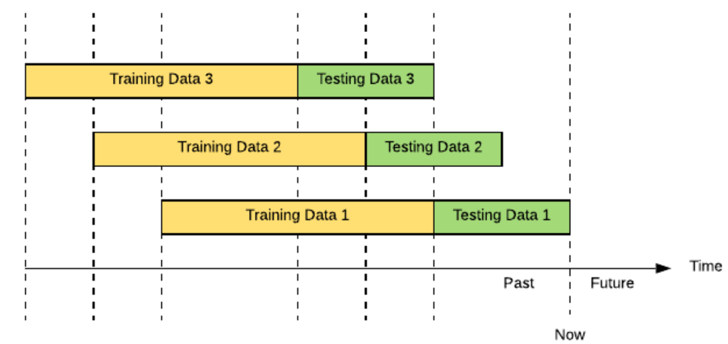

# Expanding Window

A técnica de Expanding Windows é parecida com a técnica de Rolling Window com uma pequena diferença. Essa técnica também é baseada em um modelo linear que é repetido iterativamente com uma nova amostra dos dados, entretanto, nesta técnica, o tamanho da amostra não é fixo. Diferente da técnica anterior, a janela de amostra é aumentada a cada nova iteração, conforme apresentado abaixo:

Na primeira iteração, a amostra da técnica de Expanding Window é identica a primeira amostra da técnica Rolling Window, ou seja, o valor de $\beta$ para o dia $\small m+1$ é calculado sobre uma amostra de $\small m$ dias.

Na seguinte iteração, o $\beta$ é agora calculado sobre um amostra de $\small m+1$ dias, onde o início da amostra permanece inalterado (dia 1 da série) e o fim da amostra ocorre 1 dia após.

Seguindo a mesma lógica, são feitas então as demais iterações, onde a cada nova iteração a amostra é aumentada em 1 dia (inicio no 1<sup>o</sup> dia e término no dia anterior ao dia de interesse).

Um fato relevante é que na última amostra, todos os dados da série são usados e portanto esse último $\beta$ é igual ao $\beta$ do Modelo Linear Estático. Sendo assim, ao plotar um gráfico de $\small dias$ vs. $\beta$ + linha $\beta_{estático}$, ver-se-á um gráfico onde o $\beta$ tende a se aproximar cada vez mais do valor estático ao final da série.

##### Expanding Window Example [^2^]

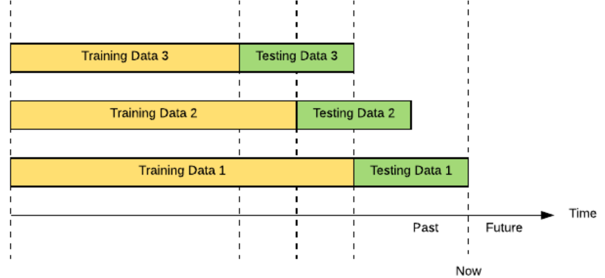

# Betas Variantes no tempo (Time-Varying Betas)

### Tsay - An Intr Analysis of Financial Data With R - 5.3.1

O modelo de Time-Varying Betas do livro Tsay, considera o $\beta$ como um coeficiente variante no tempo. Nesse caso, é feita também uma aproximação em que não é considerada como variável independente o excesso retorno $\small R_{Asset} - R_{RiskFree}$, mas sim o $\small R_{Asset}$. Sendo assim a equação de CAPM é simplificada para $\small R_{Mercado} = R_{RiskFree} + \beta R_{Asset}$.

Para esse cálculo, é utilizado o princípio estatítico:

$\small Var(x_t + y_t) = Var(x_t) + 2Cov(x_t , y_t) + Var(y_t)$ $\small Var(x_t - y_t) = Var(x_t) - 2Cov(x_t , y_t) + Var(y_t)$

Que permite isolar a covariância e calculá-la com base nas variâncias combinadas dos ativos:

$\small Cov(x_t , y_t) = {Var(x_t + y_t) − Var(x_t − y_t) \over 4}$

Dado que a volatilidade $\sigma_{x,t}$ é dada pela $\sqrt{var(x_t)}$ em um dado período, podemos então lançar mão de modelos GARCH para cálculo das variâncias ao longo do tempo e assim, calcular a Covariância. A determinação da ordem do GARCH é feita com testes de diferentes valores para m,n,modelo_GARCH(SGARCH e eGARCH),Distribuição_Erro (Normal e t-Student).

De posse do valores de Covariância, temos então que calcular a Correlação entre $x_t$ e $y_t$.

$\small Corr(x_t,y_t) = {Cov(x,y) \over \sqrt{Var(x)}\sqrt{Var(y)}} => Corr(x_t,y_t) = {Var(x_t + y_t) − Var(x_t − y_t) \over 4 \sqrt{Var(x)}\sqrt{Var(y)}}$

# DLM (Dynamic Linear Model)<sup>3</sup>

O modelo DLM considera que seus parâmetros variam no tempo. Esse modelo é um caso particular do Modelo de Espaço de Estados, que considera especificação linear e perturbações normais.

Para o modelo, considera-se a equação linear para modelos de espaço de estado, onde os estados atuais (Vetor $\theta_t$) dependem de uma combinação linear dos estados antecessores (Vetor $\theta_{t-1}$) acrescidos de um erro ($\omega_t$ - $N(0,W_t)$). A combinação linear dos estados é definida pela matriz ($G_t$). Desta forma, temos então a equação:

$\theta_t=G_t\theta_{t-1}+\omega_t$

Essa equação entretanto, utiliza os vetores de estado, que são diferentes dos valores observados, uma vez que esses últimos são compostos dos estados adicionados de um ruído. Faz-se necessário definir então a equação que descreve os espaços de estado em relação ao vetor de observações. Essa definição é apresentada a seguir:

- $y_t=F^T_t\theta_t+\upsilon_t$

onde:

- $y_t$ - Vetor de Observações
- $F^T_t$ - Tranposta da Matriz combinação linear $F_t$
- $\upsilon_t$ - ruído $N(0,V_t)$

Para completar o modelo, é necessário definir um estado inicial ($\theta_0 \sim N(m_0,C_0)$) e as matrizes de Variância-Covariancia dos ruídos observado ($\upsilon_t \sim N(0,V_t)$) e estimado ($\omega_t \sim N(0,W_t)$)

Uma vez definido o modelo, é necessário agora um algoritmo para resolvê-lo. Neste caso, será utilizado o Algoritmo do Filtro de Kalman.

<sup>3</sup> Definições adaptadas de: https://www.quantstart.com/articles/State-Space-Models-and-the-Kalman-Filter/

# Importando as cotações históricas

As análises usaram 4 papéis negociados na bolsa brasileira B3 em relação ao indíce IBOVESPA (100 principais ações da Bovespa). Os papéis são:

- Companhia Vale do Rio Doce - VALE3.SA
  - Companhia de Extração Mineral
- Petrobrás - PETR4.SA
  - Companhia de Exploração de Petróleo
- Via Varejo - VVAR3.SA
  - Companhia do ramo de consumo varejista
- CEMIG - CMIG4.SA
  - Companhia do ramo de energia
- IBOVESPA - ^BVSP

# Ações - Petrobrás

```
##      Index            PETR4.SA.Adjusted
##  Min.   :2007-01-02   Min.   : 3.896
##  1st Qu.:2010-06-28   1st Qu.:14.665
##  Median :2013-12-17   Median :18.624
##  Mean   :2013-12-18   Mean   :19.343
##  3rd Qu.:2017-06-14   3rd Qu.:24.088
##  Max.   :2020-11-26   Max.   :42.204
```

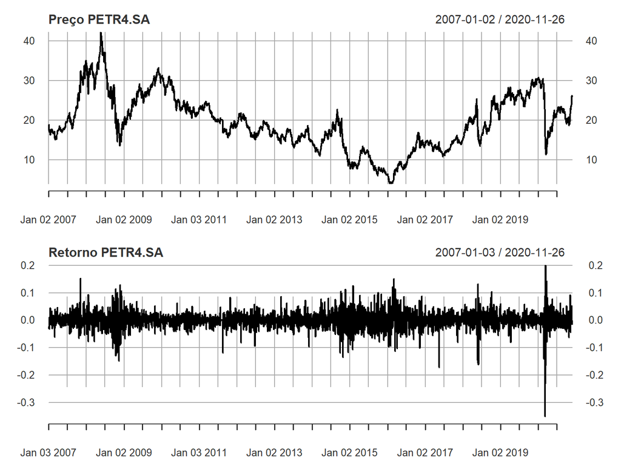

# Ações - Vale do Rio Doce

```
##      Index            VALE3.SA.Adjusted
##  Min.   :2007-01-02   Min.   : 7.357
##  1st Qu.:2010-06-28   1st Qu.:23.162
##  Median :2013-12-17   Median :28.150
##  Mean   :2013-12-18   Mean   :30.445
##  3rd Qu.:2017-06-14   3rd Qu.:37.165
##  Max.   :2020-11-26   Max.   :76.570
```

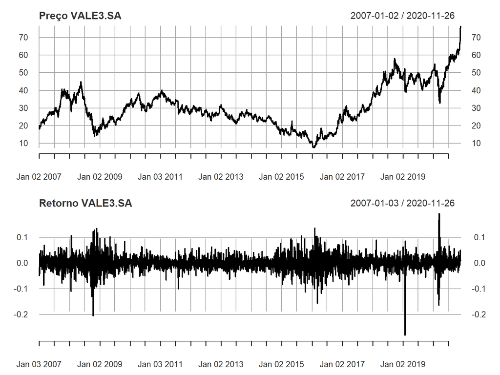

# Ações - Via Varejo

```
##      Index            VVAR3.SA.Adjusted
##  Min.   :2007-01-02   Min.   : 1.025
##  1st Qu.:2010-06-28   1st Qu.: 3.239
##  Median :2013-12-17   Median : 4.913
##  Mean   :2013-12-18   Mean   : 5.397
##  3rd Qu.:2017-06-14   3rd Qu.: 6.840
##  Max.   :2020-11-26   Max.   :21.290
```

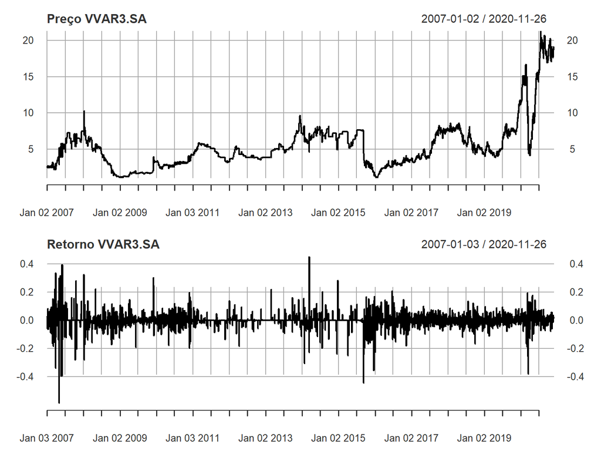

# Ações - CEMIG

```
##      Index            CMIG4.SA.Adjusted
##  Min.   :2007-01-02   Min.   : 2.980
##  1st Qu.:2010-06-28   1st Qu.: 6.806
##  Median :2013-12-17   Median : 7.794
##  Mean   :2013-12-18   Mean   : 8.325
##  3rd Qu.:2017-06-14   3rd Qu.: 9.271
##  Max.   :2020-11-26   Max.   :14.894
```

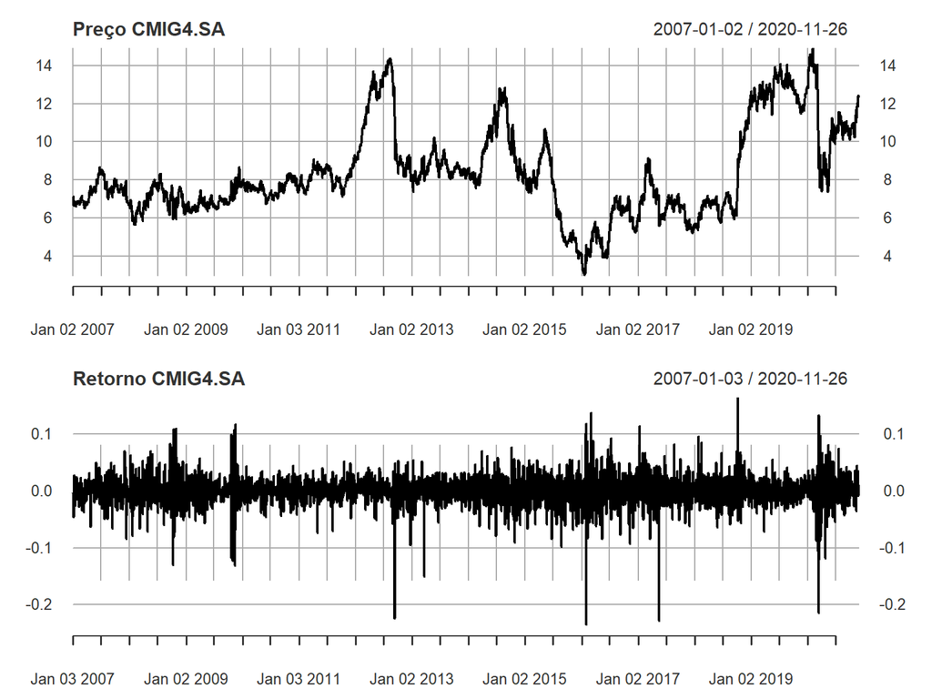

# Ações - Ibovespa

```
##      Index            BVSP.Adjusted
##  Min.   :2007-01-02   Min.   : 29435
##  1st Qu.:2010-06-28   1st Qu.: 52774
##  Median :2013-12-17   Median : 60460
##  Mean   :2013-12-18   Mean   : 64535
##  3rd Qu.:2017-06-14   3rd Qu.: 70408
##  Max.   :2020-11-26   Max.   :119528
```

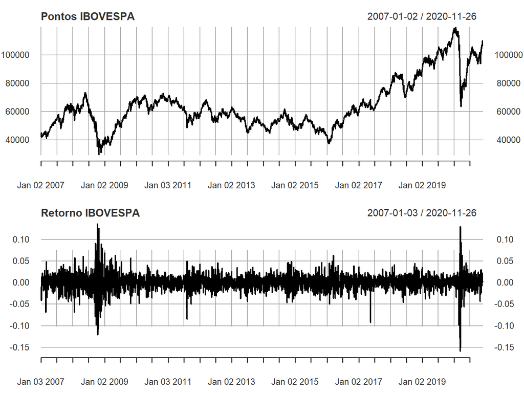

# Calculando Beta Linear Estático - Petrobrás

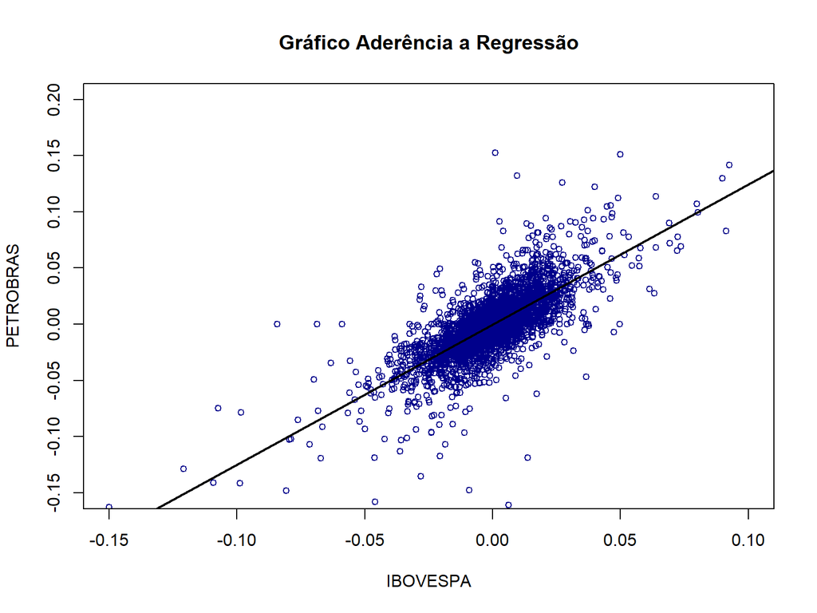

O valor do $\beta_{est_{petr}}$ é 1.2466625.

MSE = 0.0003827

MAE = 0.0135211

# Calculando Beta Linear Estático - Vale

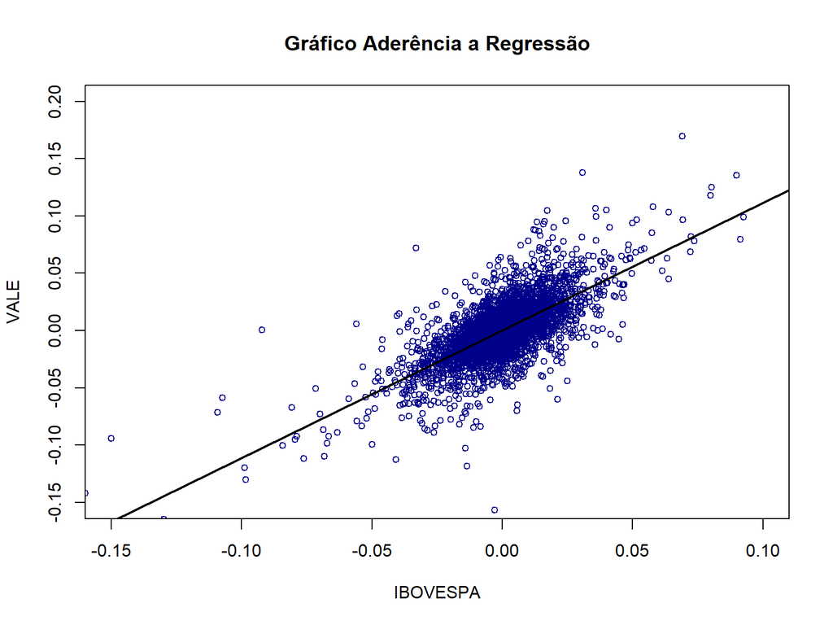

O valor do $\beta_{est_{vale}}$ é 1.1126071.

MSE = 0.0003923

MAE = 0.0139438

# Calculando Beta Linear Estático - Via Varejo

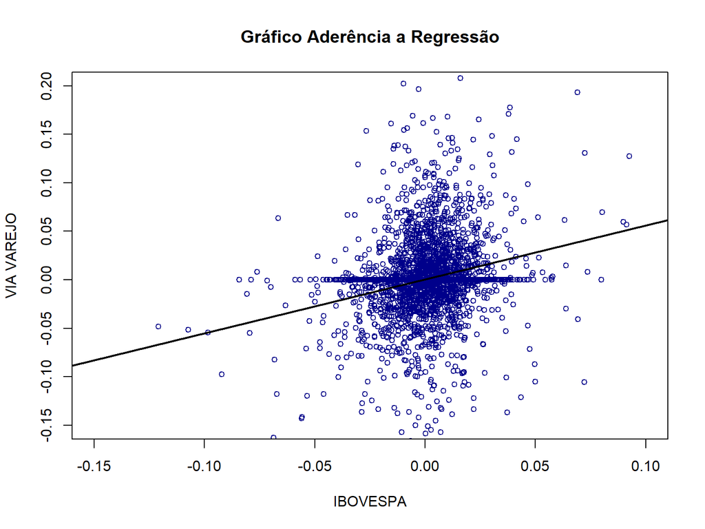

O valor do $\beta_{est_{vvar}}$ é 0.5558374.

MSE = 0.0024411

MAE = 0.0263146

# Calculando Beta Linear Estático - Cemig

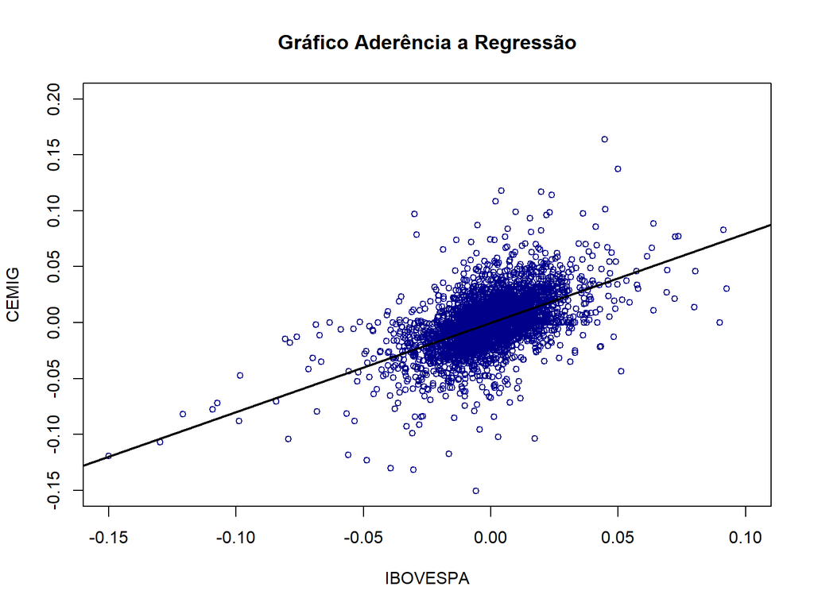

O valor do $\beta_{est_{cmig}}$ é 0.7990414.

MSE = 0.0004892

MAE = 0.0155617

# Betas e erros Lineares Estáticos - Resumo

| Petrobras | Vale | Via_Varejo | Cemig |
| --- | --- | --- | --- |
| 1.247 | 1.113 | 0.556 | 0.799 |
| 0.038 | 0.039 | 0.244 | 0.049 |
| 1.352 | 1.394 | 2.631 | 1.556 |

As ações da Petrobrás e Vale apresentaram $\beta s$ maiores que 1, o que denota um risco mais elevado que o do IBOVESPA, enquanto os $\beta s$ da Via Varejo e CEMIG, apresentam um risco menor que o IBOVESPA, dado que possuem valores menores que 1.

# Calculando Beta Linear Iterativo (Rolling Window)

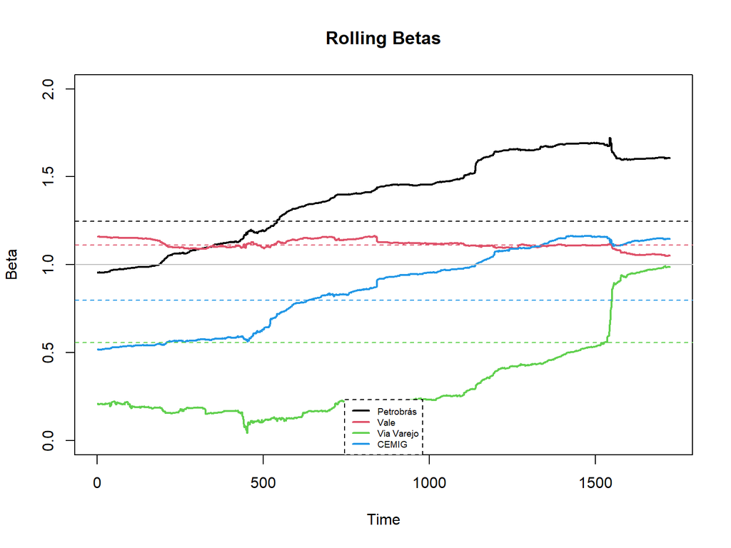

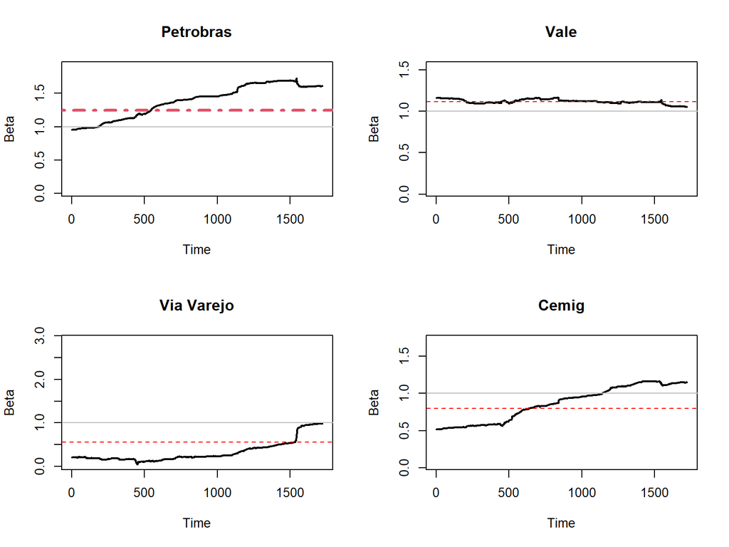

# Comparação dos resultados (Rolling x Estático)

A tabela abaixo, apresenta a propoção do erro do Modelo Rolling Window em relação ao Modelo Estático. Para essa comparação foram usadas 2 métricas:

- MSE: Mean Square Error
- MAE: Mean Absolute Error

A proporção foi calculada dividindo o valor obtido no modelo Rolling dividido pelo valor obtido no modelo estático:

$MSE={MSE_{Rolling} \over MSE_{Estático}}$

$MAE={MAE_{Rolling} \over MAE_{Estático}}$

|  | PETR | VALE | VVAR | CMIG |
| --- | --- | --- | --- | --- |
| MSE_ROL_EST | 1.241 | 1.516 | 0.901 | 1.094 |
| MAE_ROL_EST | 1.140 | 1.251 | 1.002 | 1.083 |

# Calculando Beta Linear Iterativo (Expanding Window)

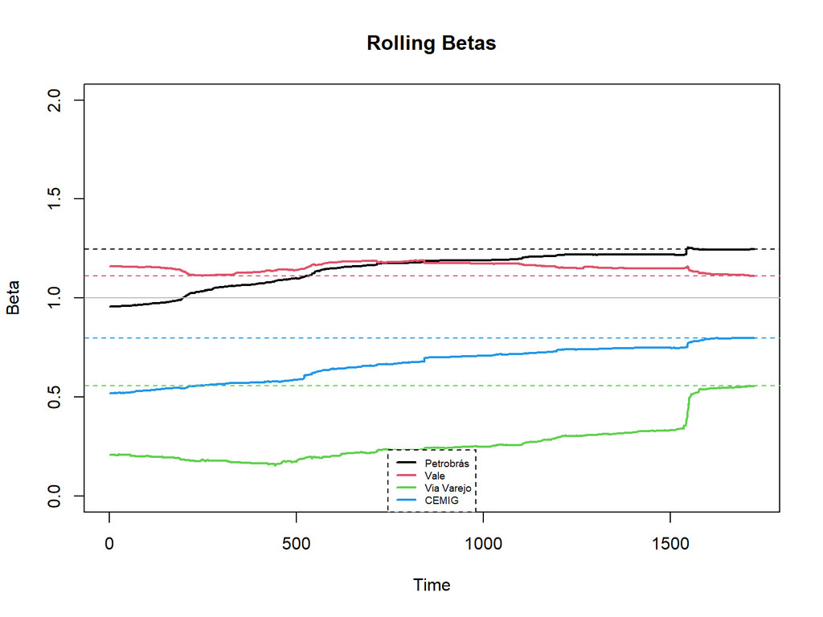

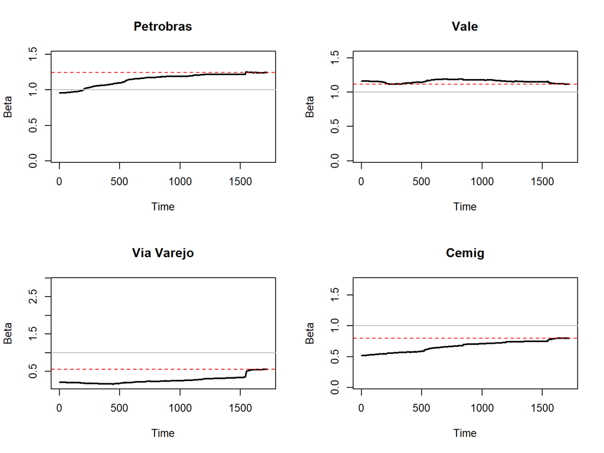

# Comparação dos resultados (Expanding x Estático)

A tabela abaixo, apresenta a propoção do erro do Modelo Expanding Window em relação ao Modelo Estático. Para essa comparação foram usadas 2 métricas:

- MSE: Mean Square Error
- MAE: Mean Absolute Error

A proporção foi calculada dividindo o valor obtido no modelo Expanding dividido pelo valor obtido no modelo estático

$MSE={MSE_{Expanding} \over MSE_{Estático}}$

$MAE={MAE_{Expanding} \over MAE_{Estático}}$

|  | PETR | VALE | VVAR | CMIG |
| --- | --- | --- | --- | --- |
| MSE_EXP_EST | 1.273 | 1.522 | 0.932 | 1.154 |
| MAE_EXP_EST | 1.138 | 1.255 | 1.020 | 1.106 |

# Timing Varying Betas (TVB) - CAPM com modelo de volatilidade

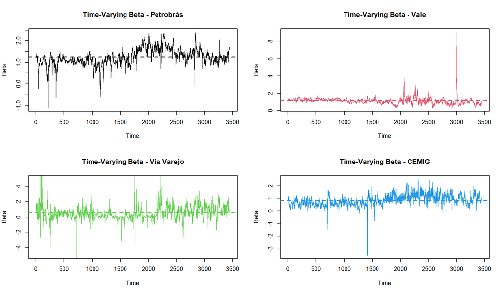

# Comparação dos resultados (TVB x Estático)

A tabela abaixo, apresenta a propoção do erro do Modelo TVB em relação ao Modelo Estático. Para essa comparação foram usadas 2 métricas:

- MSE: Mean Square Error
- MAE: Mean Absolute Error

A proporção foi calculada dividindo o valor obtido no modelo TVB dividido pelo valor obtido no modelo estático

$MSE={MSE_{TVB} \over MSE_{Estático}}$| e |$MAE={MAE_{TVB} \over MAE_{Estático}}$

|  | PETR | VALE | VVAR | CMIG |
| --- | --- | --- | --- | --- |
| MSE_TVB_EST | 0.918 | 1.023 | 0.999 | 1.005 |
| MAE_TVB_EST | 0.959 | 0.995 | 0.987 | 0.986 |

Ações que indicam mudança de risco da empresa ao longo do tempo:

- Petrobras: melhor desempenho do modelo Beta dinâmico em relação ao Beta estático
- Via Varejo: possui uma melhora no erro do backtest, mas bem menos significativo

Ações que o Beta varia com menos intensidade ao longo do tempo e o Beta estático produz resultado semelhante no longo prazo:

- Vale do Rio Doce
- Cemig

# DLM - Petrobrás

### Modelo Normal e Suavizado

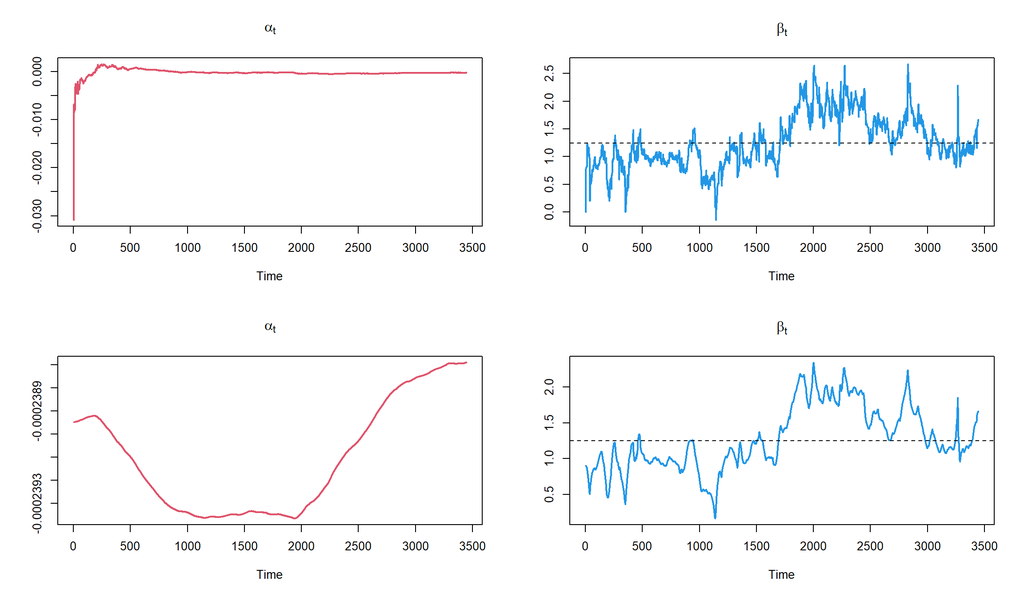

# DLM - Vale

### Modelo Normal e Suavizado

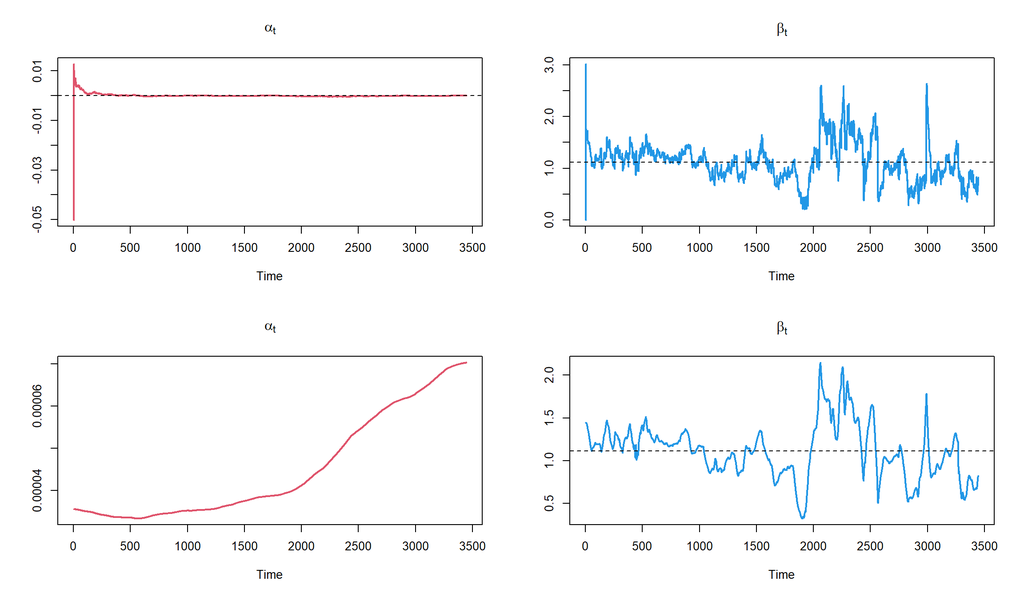

# DLM - Via Varejo

### Modelo Normal e Suavizado

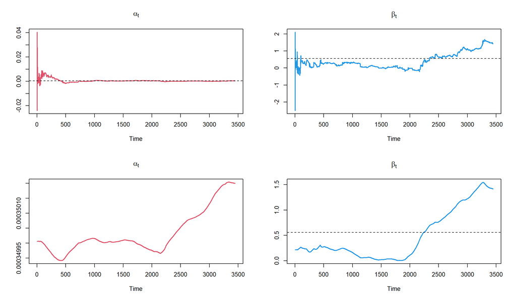

# DLM - CEMIG

### Modelo Normal e Suavizado

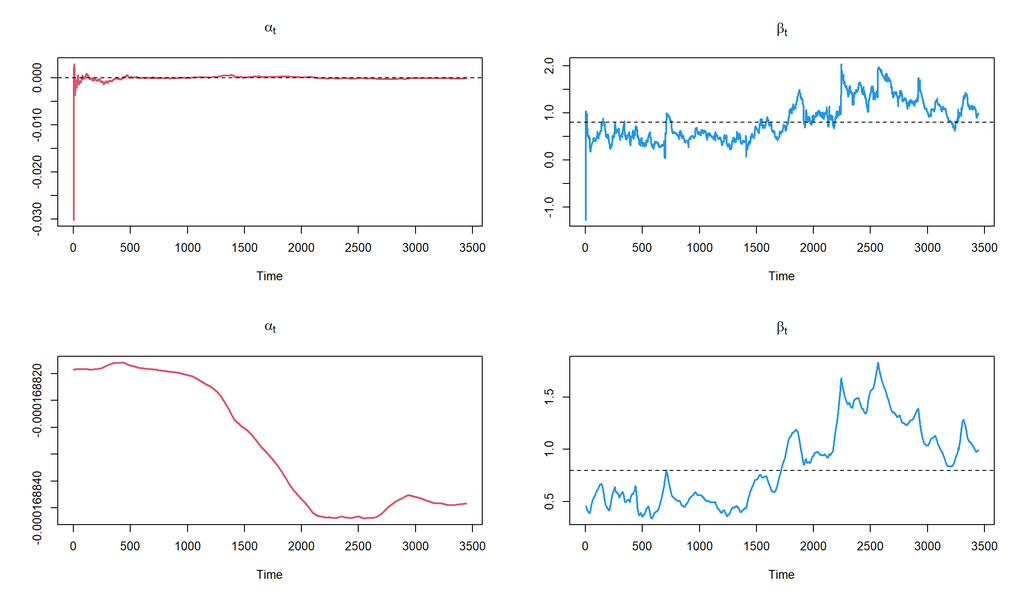

# Comparação dos resultados (DLM x Estático)

A tabela abaixo, apresenta a propoção do erro do Modelo DLM em relação ao Modelo Estático. Para essa comparação foram usadas 2 métricas:

- MSE: Mean Square Error
- MAE: Mean Absolute Error

A proporção foi calculada dividindo o valor obtido no modelo DLM dividido pelo valor obtido no modelo estático

$MSE={MSE_{DLM} \over MSE_{Estático}}$

$MAE={MAE_{DLM} \over MAE_{Estático}}$

|  | PETR | VALE | VVAR | CMIG |
| --- | --- | --- | --- | --- |
| MSE_DLM_EST | 0.897 | 0.993 | 0.976 | 0.943 |
| MAE_DLM_EST | 0.953 | 0.990 | 0.924 | 0.965 |

# Resumo final dos Modelos

Comparativo da performance dos modelos, buscando aquele que obteve melhor performance para cada ativo.

| Acao | Erro | Melhor_Modelo | Valor_sobre_Estatico |
| --- | --- | --- | --- |
| PETR | MSE | DLM | 0.897 |
| PETR | MAE | DLM | 0.953 |
| VALE | MSE | DLM | 0.993 |
| VALE | MAE | DLM | 0.990 |
| VVAR | MSE | Rolling | 0.901 |
| VVAR | MAE | DLM | 0.924 |
| CMIG | MSE | DLM | 0.943 |
| CMIG | MAE | DLM | 0.965 |